# Alina’s PhD Data Analysis Notebook

```r
library(tidyverse)
library(tidyr)
```

## Setting the Stage

1. A set of 13 different tables provided
2. Objective: To determine relationships/correlations between different variables of the table.

## EDA

1. Reduce Variables and clean up names
2. Clean up missing Values
3. Perform Basic Visualization
4. Remove Outliers - 3 different approaches
5. Filter out outlier values based on statistical approaches
6. Hypothesis to check?

```r
d1 <- read.csv("~/R/Rtuts/Data/C57BL6_476_vs_C57BL6_ctl.csv")
head(d1)
```

|  | ensembl_gene_id | baseMean | log2FoldChange | lfcSE | stat | pvalue | padj | symbol | CPM_.C57BL6_476_R1. | CPM_.C57BL6_476_R2. | CPM_.C57BL6_ctl_R1. | CPM_.C57BL6_ctl_R2. |
| --- | --- | --- | --- | --- | --- | --- | --- | --- | --- | --- | --- | --- |
| 1 | ENSMUSG00000000001 | 945.29834 | -0.24087033 | 0.4705517 | -0.5118891 | 0.6087286020 | 0.945817442 | Gnai3 | 50.257712 | 95.341620 | 81.511051 | 85.536961 |
| 2 | ENSMUSG00000000028 | 49.93187 | 0.51675189 | 0.4071793 | 1.2691016 | 0.2044048320 | 0.776684281 | Cdc45 | 5.222461 | 4.683448 | 3.145561 | 3.578952 |
| 3 | ENSMUSG00000000031 | 1877.69986 | 0.08157969 | 0.1320235 | 0.6179179 | 0.5366294590 | 0.929504895 | H19 | 181.836605 | 144.183291 | 150.303095 | 147.631785 |
| 4 | ENSMUSG00000000056 | 200.91458 | -0.40341459 | 0.2715208 | -1.4857594 | 0.1373427690 | 0.710718209 | Narf | 13.564834 | 15.723004 | 23.523323 | 13.600019 |
| 5 | ENSMUSG00000000078 | 1454.74864 | -0.70729126 | 0.1627415 | -4.3461036 | 0.0000138577 | 0.001934374 | Klf6 | 80.303820 | 106.158154 | 162.406666 | 131.347552 |
| 6 | ENSMUSG00000000085 | 277.24364 | -0.09736087 | 0.1941322 | -0.5015185 | 0.6160062560 | 0.946194444 | Scmh1 | 23.467164 | 21.744580 | 24.207141 | 22.547400 |

```r
str(d1)
```

```
'data.frame':   11865 obs. of  12 variables:
 $ ensembl_gene_id    : chr  "ENSMUSG00000000001" "ENSMUSG00000000028" "ENSMUSG00000000031" "ENSMUSG00000000056" ...
 $ baseMean           : num  945.3 49.9 1877.7 200.9 1454.7 ...
 $ log2FoldChange     : num  -0.2409 0.5168 0.0816 -0.4034 -0.7073 ...
 $ lfcSE              : num  0.471 0.407 0.132 0.272 0.163 ...
 $ stat               : num  -0.512 1.269 0.618 -1.486 -4.346 ...
 $ pvalue             : num  6.09e-01 2.04e-01 5.37e-01 1.37e-01 1.39e-05 ...
 $ padj               : num  0.94582 0.77668 0.9295 0.71072 0.00193 ...
 $ symbol             : chr  "Gnai3" "Cdc45" "H19" "Narf" ...
 $ CPM_.C57BL6_476_R1.: num  50.26 5.22 181.84 13.56 80.3 ...
 $ CPM_.C57BL6_476_R2.: num  95.34 4.68 144.18 15.72 106.16 ...
 $ CPM_.C57BL6_ctl_R1.: num  81.51 3.15 150.3 23.52 162.41 ...
 $ CPM_.C57BL6_ctl_R2.: num  85.54 3.58 147.63 13.6 131.35 ...
```

Removing unneccesary columns to reduce the table!

```r
d2 <- select(d1, -lfcSE, -stat, -symbol)
head(d2)
```

|  | ensembl_gene_id | baseMean | log2FoldChange | pvalue | padj | CPM_.C57BL6_476_R1. | CPM_.C57BL6_476_R2. | CPM_.C57BL6_ctl_R1. | CPM_.C57BL6_ctl_R2. |
| --- | --- | --- | --- | --- | --- | --- | --- | --- | --- |
| 1 | ENSMUSG00000000001 | 945.29834 | -0.24087033 | 0.6087286020 | 0.945817442 | 50.257712 | 95.341620 | 81.511051 | 85.536961 |
| 2 | ENSMUSG00000000028 | 49.93187 | 0.51675189 | 0.2044048320 | 0.776684281 | 5.222461 | 4.683448 | 3.145561 | 3.578952 |
| 3 | ENSMUSG00000000031 | 1877.69986 | 0.08157969 | 0.5366294590 | 0.929504895 | 181.836605 | 144.183291 | 150.303095 | 147.631785 |
| 4 | ENSMUSG00000000056 | 200.91458 | -0.40341459 | 0.1373427690 | 0.710718209 | 13.564834 | 15.723004 | 23.523323 | 13.600019 |
| 5 | ENSMUSG00000000078 | 1454.74864 | -0.70729126 | 0.0000138577 | 0.001934374 | 80.303820 | 106.158154 | 162.406666 | 131.347552 |
| 6 | ENSMUSG00000000085 | 277.24364 | -0.09736087 | 0.6160062560 | 0.946194444 | 23.467164 | 21.744580 | 24.207141 | 22.547400 |

```r
str(d2)
```

```
'data.frame':   11865 obs. of  9 variables:
 $ ensembl_gene_id    : chr  "ENSMUSG00000000001" "ENSMUSG00000000028" "ENSMUSG00000000031" "ENSMUSG00000000056" ...
 $ baseMean           : num  945.3 49.9 1877.7 200.9 1454.7 ...
 $ log2FoldChange     : num  -0.2409 0.5168 0.0816 -0.4034 -0.7073 ...
 $ pvalue             : num  6.09e-01 2.04e-01 5.37e-01 1.37e-01 1.39e-05 ...
 $ padj               : num  0.94582 0.77668 0.9295 0.71072 0.00193 ...
 $ CPM_.C57BL6_476_R1.: num  50.26 5.22 181.84 13.56 80.3 ...
 $ CPM_.C57BL6_476_R2.: num  95.34 4.68 144.18 15.72 106.16 ...
 $ CPM_.C57BL6_ctl_R1.: num  81.51 3.15 150.3 23.52 162.41 ...
 $ CPM_.C57BL6_ctl_R2.: num  85.54 3.58 147.63 13.6 131.35 ...
```

Rename the Variable names into more readable ones!

```r
d3 <- d2 %>% rename(CPM_476_R1 = CPM_.C57BL6_476_R1.) %>% rename(CPM_476_R2 = CPM_.C57BL6_476_R2.) %>% rename(CPM_ctl_R1 = CPM_.C57BL6_ctl_R1.)  %>% rename(CPM_ctl_R2 = CPM_.C57BL6_ctl_R2.)
head(d3)
```

|  | ensembl_gene_id | baseMean | log2FoldChange | pvalue | padj | CPM_476_R1 | CPM_476_R2 | CPM_ctl_R1 | CPM_ctl_R2 |
| --- | --- | --- | --- | --- | --- | --- | --- | --- | --- |
| 1 | ENSMUSG00000000001 | 945.29834 | -0.24087033 | 0.6087286020 | 0.945817442 | 50.257712 | 95.341620 | 81.511051 | 85.536961 |
| 2 | ENSMUSG00000000028 | 49.93187 | 0.51675189 | 0.2044048320 | 0.776684281 | 5.222461 | 4.683448 | 3.145561 | 3.578952 |
| 3 | ENSMUSG00000000031 | 1877.69986 | 0.08157969 | 0.5366294590 | 0.929504895 | 181.836605 | 144.183291 | 150.303095 | 147.631785 |
| 4 | ENSMUSG00000000056 | 200.91458 | -0.40341459 | 0.1373427690 | 0.710718209 | 13.564834 | 15.723004 | 23.523323 | 13.600019 |
| 5 | ENSMUSG00000000078 | 1454.74864 | -0.70729126 | 0.0000138577 | 0.001934374 | 80.303820 | 106.158154 | 162.406666 | 131.347552 |
| 6 | ENSMUSG00000000085 | 277.24364 | -0.09736087 | 0.6160062560 | 0.946194444 | 23.467164 | 21.744580 | 24.207141 | 22.547400 |

```r
summary(d3)
```

```
 ensembl_gene_id       baseMean        log2FoldChange           pvalue            padj
 Length:11865       Min.   :    23.6   Min.   :-10.413970   Min.   :0.0000   Min.   :0.0000
 Class :character   1st Qu.:    91.3   1st Qu.: -0.175420   1st Qu.:0.1924   1st Qu.:0.7693
 Mode  :character   Median :   252.2   Median :  0.000043   Median :0.4577   Median :0.9150
                    Mean   :  1011.9   Mean   :  0.000099   Mean   :0.4638   Mean   :0.8245
                    3rd Qu.:   652.6   3rd Qu.:  0.164444   3rd Qu.:0.7260   3rd Qu.:0.9677
                    Max.   :650997.3   Max.   : 10.186375   Max.   :0.9999   Max.   :0.9999
   CPM_476_R1         CPM_476_R2         CPM_ctl_R1         CPM_ctl_R2
 Min.   :    0.00   Min.   :    0.00   Min.   :    0.00   Min.   :    0.00
 1st Qu.:    7.73   1st Qu.:    7.69   1st Qu.:    7.32   1st Qu.:    7.43
 Median :   21.09   Median :   21.08   Median :   20.38   Median :   20.58
 Mean   :   83.92   Mean   :   83.93   Mean   :   83.93   Mean   :   83.94
 3rd Qu.:   54.60   3rd Qu.:   54.19   3rd Qu.:   53.00   3rd Qu.:   53.15
 Max.   :37654.49   Max.   :47897.85   Max.   :77454.03   Max.   :51879.69
```

### Question1 :

What does the value 0.0 in the min for CPM indicate? Is it a real value or worthy to be discarded?

### Checking Missing Values

```r
glimpse(d3)
```

```
Rows: 11,865
Columns: 9
$ ensembl_gene_id <chr> "ENSMUSG00000000001", "ENSMUSG00000000028", "ENSMUSG00000000031", "E~
$ baseMean        <dbl> 945.29834, 49.93187, 1877.69986, 200.91458, 1454.74864, 277.24364, 3~
$ log2FoldChange  <dbl> -0.24087033, 0.51675189, 0.08157969, -0.40341459, -0.70729126, -0.09~
$ pvalue          <dbl> 0.6087286020, 0.2044048320, 0.5366294590, 0.1373427690, 0.0000138577~
$ padj            <dbl> 0.945817442, 0.776684281, 0.929504895, 0.710718209, 0.001934374, 0.9~
$ CPM_476_R1      <dbl> 50.257712, 5.222461, 181.836605, 13.564834, 80.303820, 23.467164, 31~
$ CPM_476_R2      <dbl> 95.341620, 4.683448, 144.183291, 15.723004, 106.158154, 21.744580, 3~
$ CPM_ctl_R1      <dbl> 81.511051, 3.145561, 150.303095, 23.523323, 162.406666, 24.207141, 2~
$ CPM_ctl_R2      <dbl> 85.536961, 3.578952, 147.631785, 13.600019, 131.347552, 22.547400, 3~
```

```r
d3 %>% summarise(c1 = sum(is.na(CPM_476_R1)),
                 c2 = sum(is.na(CPM_476_R2)),
                 c3 = sum(is.na(CPM_ctl_R1)),
                 c4 = sum(is.na(CPM_ctl_R1))
                 )
```

| c1 | c2 | c3 | c4 |
| --- | --- | --- | --- |
| 0 | 0 | 0 | 0 |

Therefore, there are no missing values in the table.

## Basic Visualization to get a sneak peak at Data!

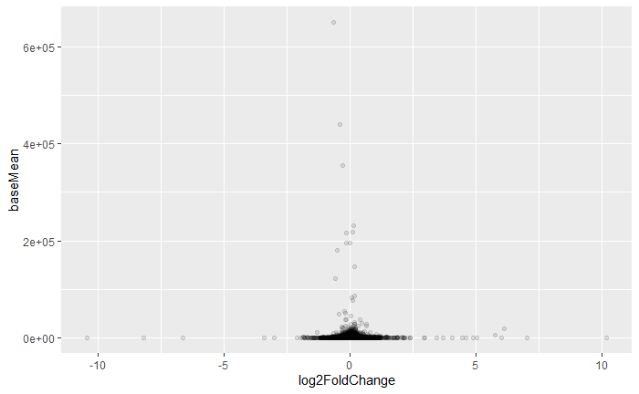

```r
ggplot(data = d3, mapping = aes(x = log2FoldChange, y = baseMean)) + geom_point(alpha = 0.1)
```

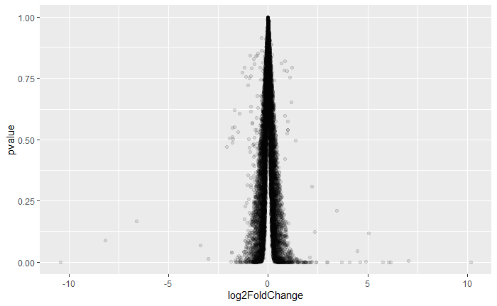

```r
ggplot(data = d3, mapping = aes(x = log2FoldChange, y = pvalue)) + geom_point(alpha = 0.1)
```

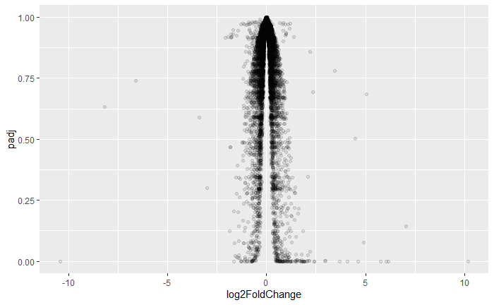

```r
ggplot(data = d3, mapping = aes(x = log2FoldChange, y = padj)) + geom_point(alpha = 0.1)
```

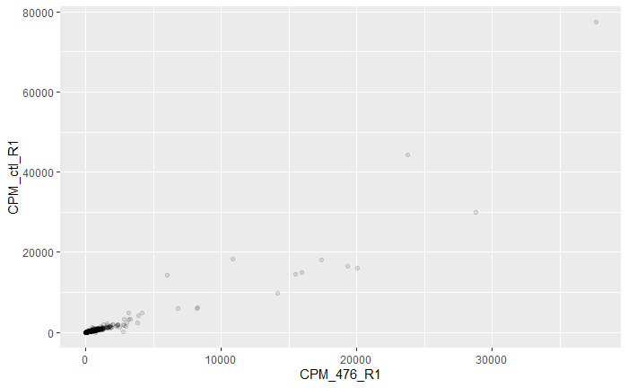

```r
ggplot(data = d3, mapping = aes(x = CPM_476_R1, y = CPM_ctl_R1)) + geom_point(alpha = 0.1)
```

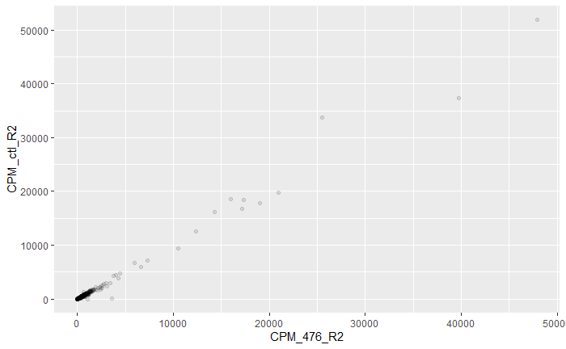

```r
ggplot(data = d3, mapping = aes(x = CPM_476_R2, y = CPM_ctl_R2)) + geom_point(alpha = 0.1)
```

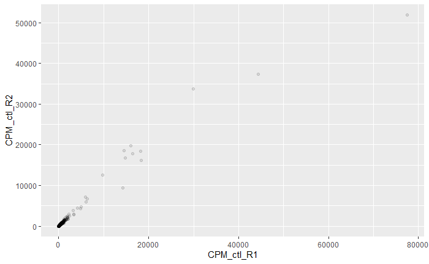

```r
ggplot(data = d3, mapping = aes(x = CPM_ctl_R1, y = CPM_ctl_R2)) + geom_point(alpha = 0.1)
```

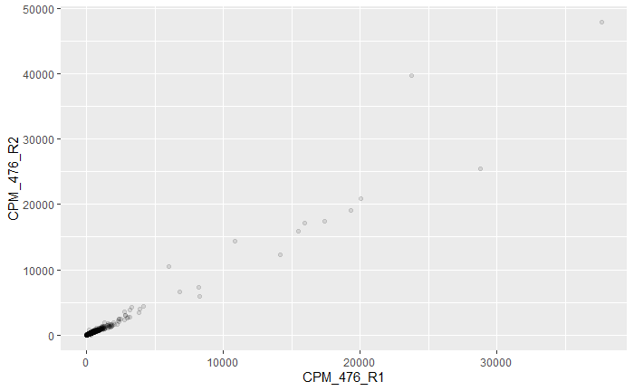

```r
ggplot(data = d3, mapping = aes(x = CPM_476_R1, y = CPM_476_R2)) + geom_point(alpha = 0.1)
```

### Hence, there exists major issue with “Outliers” in data, making the data skewed on the wrong end!

## Removing Outliers

Calculating Standard Deviation from current table gives misplaced picture. Hence, remove outliers and then calculate standard deviation to place meaningful thresholds!

The best way to look for outliers in two numeric variables is using a scatter plot.

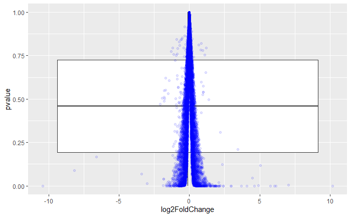

```r
ggplot(data = d3, mapping = aes(x = log2FoldChange, y = pvalue)) + geom_boxplot() + geom_point(alpha = 0.1, color = "blue")
```

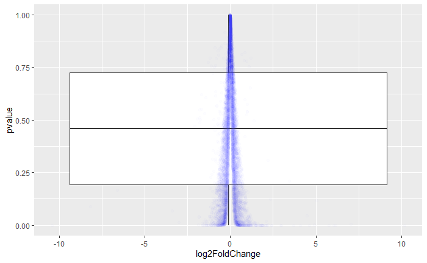

```r
ggplot(data = d3, mapping = aes(x = log2FoldChange, y = pvalue)) + geom_boxplot() + geom_point(alpha = 0.009, color = "blue")
```

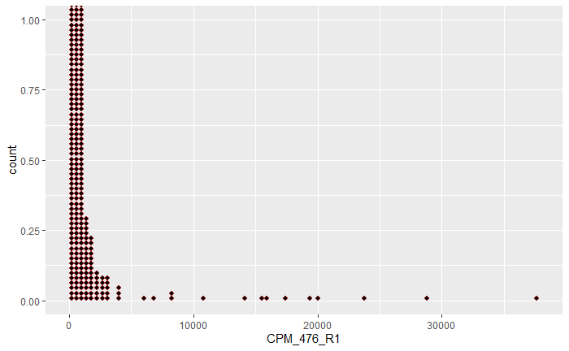

```r
ggplot(data = d3, mapping = aes(x = CPM_476_R1)) + geom_dotplot(binwidth = 400, color = "brown")
```

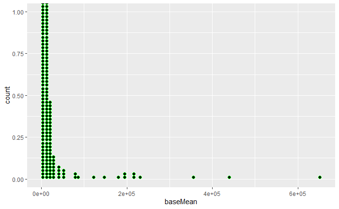

```r
ggplot(data = d3, mapping = aes(x = baseMean)) + geom_dotplot(binwidth = 8000, color = "green")
```

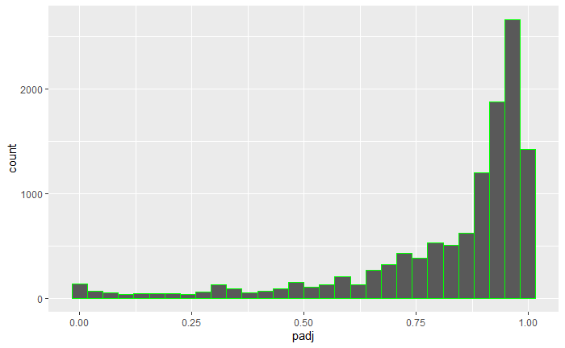

```r
ggplot(data = d3, mapping = aes(x = padj)) + geom_histogram( color = "green")
```

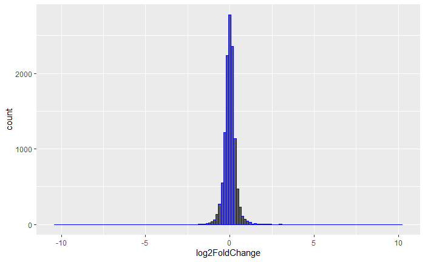

```r
ggplot(data = d3, mapping = aes(x = log2FoldChange)) + geom_histogram(binwidth = 0.15, color = "blue")
```

### Question 2:

The values of other variables are derived from a (some particular) transformation of CPM values? If yes, then filtering outliers from CPM will also remove values from other variables and could lead elimination of certain genes. Would that create a problem?

### Question 3:

No wrongly tabulated or mistakenly tabulated data? More an Art than Science!

### Question 4: Which approach to pick for removing outliers?

1. Hard cut as a threshold based on visualization.
2. Based on Z-scores.
3. Based on IQR.
4. Based on Spread and variability of data : 1sigma, 2 sigma and 3 sigman spread.